# MA 589 Project 3

Wenbin Teng

October 19, 2018

1. A traffic engineer requests your help in identifying “black spots” in his city. He has data on the number of accidents $X$ in one year at $n = 20$ traffic intersections:

$$\left[\begin{array}
{lrrrrrrrrrrrrr}
i & 1 & 2 & 3 & 4 & 5 & 6 & 7 & 8 & 9 & 10 & 11 & 12 & 13 & 14 & 15 & 16 & 17 & 18 & 19 & 20\\
X_i & 2 & 0 & 0 & 1 & 3 & 0 & 1 & 6 & 2 & 0 & 1 & 0 & 2 & 0 & 8 & 0 & 1 & 3 & 2 & 0\\
\end{array}\right]$$

After discussing with him, you both agree to model the number of accidents $X_i$ at intersection $i$ using a mixture of Poisson distributions,

$$X_i|Z_i \stackrel{iid}\sim\texttt{Po}(Z_i\lambda_d+(1-Z_i)\lambda_c)$$
$$Z_i \stackrel{iid}\sim\texttt{Bern}(\pi),$$
where $Z_i = 1$ identifies the $i$-th intersection as being “dangerous” with a higher rate of accidents per year $\lambda_d$ and $Z_i = 0$ codes for the intersection being “calm”, with a smaller rate $\lambda_c$. Your task is to exploit the latent variable ($Z$) formulation above and estimate $\pi$, $\lambda_c$, and $\lambda_d$ using expectation-maximization.

1. Derive E-step of your EM algorithm: write the complete data log likelihood, and then the expected log likelihood $Q$ by showing that

$$\begin{split}
\alpha_{i}^{(t)} & =\mathbf{E}_{Z|X;\pi^{(t)},\lambda_c^{(t)},\lambda_d^{(t)}}[Z_i]=\mathbf{P}(Z_i=1|X_i;\pi^{(t)},\lambda_c^{(t)},\lambda_d^{(t)})\\
& =\frac{\pi^{(t)}p(X_i;\lambda_d^{(t)})}{\pi^{(t)}p(X_i;\lambda_d^{(t)})+(1-\pi^{(t)})p(X_i;\lambda_c^{(t)})}\\
\end{split}$$

where $p(X_i; \lambda)$ is the Poisson pmf with rate $\lambda$ evaluated at $X_i$.

For simplicity, let $\theta=(\lambda_c,\lambda_d,\pi)$, we know:

$$X_i|Z_i \sim^{\text{iid}}\texttt{Po}(Z_i\lambda_d+(1-Z_i)\lambda_c)=Z_i\texttt{Po}(\lambda_d)+(1-Z_i)\texttt{Po}(\lambda_c),Z_i \sim^{\text{iid}}\texttt{Bern}(\pi)$$

$$L(\theta, X; Z)=\prod_{i=1}^{n}p(x_i,\lambda_d)^{Z_i}p(x_i,\lambda_c)^{1-Z_i}\pi^{Z_i}(1-\pi)^{1-Z_i}$$
$$l(\theta, X;Z)=\sum_{i=1}^{n}Z_i[\log{p(x_i,\lambda_d)}+\log\pi]+(1-Z_i)[\log{p(x_i,\lambda_c)}+\log{(1-\pi)}]$$
$$\begin{split}\alpha_i^{(t)}
& =\mathbf{E}_{Z|X;\theta^{(t)}}[Z_i]=\mathbf{P}(Z_i=1|X;\theta^{(t)})=\frac{\mathbf{P}(Z_i=1,X;\theta^{(t)})}{\mathbf{P}(X;\theta^{(t)})}\\
& =\frac{\sum_{Z_j\in{\big\{0,1\big\}j\neq{i}}}\mathbf{P}(\big\{Z_j\big\};Z_i=1,X;\theta^{(t)})}{\sum_{{\tilde{Z}_j}\in \big\{0,1\big\}}\mathbf{P}(Z,X;\theta^{(t)})}\\
& =\frac{\sum_{Z_j\in{\big\{0,1\big\}j\neq{i}}}\prod_{k=1,k\neq{i}}^n\mathbf{P}(x_k|Z_k;\theta^{(t)})\mathbf{P}(Z_k;\theta^{(t)})\mathbf{P}(X_i|Z_i=1;\theta^{(t)})\mathbf{P}(Z_i=1;\theta^{(t)})}{\sum_{{\tilde{Z}_j}}\prod_{k=1}^n\mathbf{P}(X_k|\tilde{Z}_j;\theta^{(t)})\mathbf{P}(\tilde{Z}_j;\theta^{(t)})}\\
& = \frac{\mathbf{P}(X_i|Z_i=1;\theta^{(t)})\mathbf{P}(Z_i=1;\theta^{(t)})}{\sum_{{\tilde{Z}_i}}\mathbf{P}(X_i|\tilde{Z_i};\theta^{(t)})\mathbf{P}(\tilde{Z_i};\theta^{(t)})}\\
& = \frac{p(X_i;\lambda_d)\pi^{(t)}}{p(X_i;\lambda_d)\pi^{(t)}+p(X_i;\lambda_c)(1-\pi^{(t)})}\end{split}$$

Therefore, the E-step of the expectation maximization is:
$$\begin{split}Q(\theta,\theta^{(t)}) & = \mathbf{E}_{Z|X;\theta^{(t)}}[l(\theta;X,Z)]\\
& = \sum_{i=1}^{n}\alpha_i^{(t)}[\log{p(X_i,\lambda_d)}+\log\pi]+(1-\alpha_i^{(t)})[\log{p(X_i,\lambda_c)}+\log{(1-\pi)}]\end{split}$$

2. Now, for the M-step, differentiate Q to obtain the update equations:
   $$\pi^{(t+1)}=\frac{\sum_{i=1}^n\alpha_i^{(t)}}{n},\lambda_c^{(t+1)}=\frac{\sum_{i=1}^n(1-\alpha_i^{(t)})X_i}{\sum_{i=1}^n(1-\alpha_i^{(t)})},\lambda_d^{(t+1)}=\frac{\sum_{i=1}^n\alpha_i^{(t)}X_i}{\sum_{i=1}^n\alpha_i^{(t)}}$$

The M-step requires taking partial derivative with respect to each parameters in $\theta$ of $Q(\theta,\theta^{(t)})$ derived from part (a). First taking partial derivative w.r.t $\pi$

$$\frac{\partial{Q(\theta,\theta^{(t)})}}{\partial{\pi}}(\pi^{(t+1)})=\sum_{i=1}^n\bigg[\frac{\alpha_i^{(t)}}{\pi}-\frac{1-\alpha_i^{(t)}}{1-\pi}\bigg]=\frac{\sum_{i=1}^n\alpha_i^{(t)}}{\pi}-\frac{n-\sum_{i=1}^n\alpha_i^{(t)}}{1-\pi}=0$$
Therefore,$\pi^{(t+1)}=\frac{\sum_{i=1}^n\alpha_i^{(t)}}{n}$

Now,let’s take derivative w.r.t $\lambda_c$ and $\lambda_d$, before that we know the PMF of possion distribution:$p(X,\lambda)=\frac{\lambda^Xe^{-\lambda}}{X!}$. Then, we have:

$$\log p(X_i,\lambda_c)=\log\frac{\lambda_c^{X_i}e^{-\lambda_c}}{X_i!}=X_i\log(\lambda_c)-\lambda_c-\log(X_i!)$$
$$\log p(X_i,\lambda_d)=\log\frac{\lambda_d^{X_i}e^{-\lambda_d}}{X_i!}=X_i\log(\lambda_d)-\lambda_d-\log(X_i!)$$

$$\frac{\partial{Q(\theta,\theta^{(t)})}}{\partial{\lambda_c}}(\lambda_c^{(t+1)})=\sum_{i=1}^n(1-\alpha_i^{(t)})\bigg[\frac{X_i}{\lambda_c}-1\bigg]=0$$
Therefore,$\lambda_c^{(t+1)}=\frac{\sum_{i=1}^n(1-\alpha_i^{(t)})X_i}{\sum_{i=1}^n(1-\alpha_i^{(t)})}$

Similarly, we have:
$$\frac{\partial{Q(\theta,\theta^{(t)})}}{\partial{\lambda_d}}(\lambda_d^{(t+1)})=\sum_{i=1}^n\alpha_i^{(t)}\bigg[\frac{X_i}{\lambda_c}-1\bigg]=0$$
Therefore, $\lambda_d^{(t+1)}=\frac{\sum_{i=1}^n\alpha_i^{(t)}X_i}{\sum_{i=1}^n\alpha_i^{(t)}}$

3. Starting at $\pi^{(0)}=0.5$,

$$\lambda_c^{(0)}=\frac{\sum_{i=1}^nX_iI(X_i<\bar{X})}{\sum_{i=1}^nI(X_i<\bar{X})}\text{ and }\lambda_d^{(0)}=\frac{\sum_{i=1}^nX_iI(X_i>\bar{X})}{\sum_{i=1}^nI(X_i>\bar{X})}$$

```r
# First upload data
x <- c(2,0,0,1,3,0,1,6,2,0,1,0,2,0,8,0,1,3,2,0)
lc <- mean(x[x<mean(x)]);ld <- mean(x[x>mean(x)])
# Calculate log-pi
log.pi <- function(x,lambda) {x*log(lambda)-lambda-log(factorial(x))}
# E-M Step
em.update <- function(x,em) {
  alpha<- (exp(log.pi(x,em$ld))*em$pi)/((exp(log.pi(x,em$ld))*em$pi)+(exp(log.pi(x,em$lc))*(1-em$pi)))
  pi <- sum(alpha)/length(x)
  lc <- sum((1-alpha)*x)/sum(1-alpha)
  ld <- sum(alpha*x)/sum(alpha)
  em <- list(pi = pi,lc = lc,ld = ld)
  em
}
# Run iteration
em.iteration <- function(x,em,tolerance=1e-8,max.iteration=100) {
  em.cur <- em
  for (it in 1:max.iteration) {
    print(paste0("pi is ",em.cur$pi,"lambda_c is ",em.cur$lc,"lambda_d is ",em.cur$ld))
    em.nxt <- em.update(x,em.cur)
    if((abs(em.nxt$pi-em.cur$pi)/em.cur$pi)<tolerance|(abs(em.nxt$lc-em.cur$lc)/em.cur$lc)<tolerance|(abs(em.nxt$ld-em.cur$ld)/em.cur$ld)<tolerance) break
    em.cur <- em.nxt
  }
  print(paste0("time is ",it))
  em.nxt
}
em <- list(pi=0.5,lc=lc,ld=ld)
em.iteration(x,em)
```

```
## [1] "pi is 0.5lambda_c is 0.333333333333333lambda_d is 3.5"
## [1] "pi is 0.440098124068822lambda_c is 0.384925258245395lambda_d is 3.14584305203402"
## [1] "pi is 0.42685635726225lambda_c is 0.42835547647814lambda_d is 3.17317701559377"
## [1] "pi is 0.410567281491397lambda_c is 0.46258893540147lambda_d is 3.23292918381789"
## [1] "pi is 0.393282288317865lambda_c is 0.494381047517256lambda_d is 3.30564152205239"
## [1] "pi is 0.375509727016008lambda_c is 0.525712854838648lambda_d is 3.38658986513126"
## [1] "pi is 0.357383187755733lambda_c is 0.557126431262592lambda_d is 3.47520877107931"
## [1] "pi is 0.338961655100699lambda_c is 0.588716584598686lambda_d is 3.57219096933663"
## [1] "pi is 0.320311474004496lambda_c is 0.620427731664896lambda_d is 3.67861436509582"
## [1] "pi is 0.301528867921057lambda_c is 0.652140548924277lambda_d is 3.79565200642055"
## [1] "pi is 0.282745430528606lambda_c is 0.683695430267775lambda_d is 3.92443593673379"
## [1] "pi is 0.264127994376245lambda_c is 0.714896019012648lambda_d is 4.06593793744913"
## [1] "pi is 0.245876113852366lambda_c is 0.745504663592637lambda_d is 4.22081311474393"
## [1] "pi is 0.228218329307427lambda_c is 0.775233389827904lambda_d is 4.38917015237898"
## [1] "pi is 0.211407395279324lambda_c is 0.80373390877143lambda_d is 4.57023455637884"
```

[output cut: 40 more lines]

```
## $pi
## [1] 0.1244548
##
## $lc
## [1] 0.9581722
##
## $ld
## [1] 6.115288
```

4. Based on your EM estimates, what is the probability of the first intersection being dangerous given $X_1$? What about the fifth intersection? Which intersections would you flag as black spots?

```r
alpha<- (exp(log.pi(x,em$ld))*em$pi)/((exp(log.pi(x,em$ld))*em$pi)+(exp(log.pi(x,em$lc))*(1-em$pi)))
alpha[1]
```

[output not shown]

```r
alpha[5]
```

```
## [1] 0.9799143
```

The itersections that have high probability are considered as black spots

5. Run your EM algorithm again, but swapping the starting values for $\lambda_c$ and $\lambda_d$ at Equation 1. Compare your estimates now to the previous values; how can you explain these results?

```r
em.flip <- list(pi=0.5,lc=ld,ld=lc)
em.iteration(x,em.flip)
```

```
## [1] "pi is 0.5lambda_c is 3.5lambda_d is 0.333333333333333"
## [1] "pi is 0.559901875931178lambda_c is 3.14584305203402lambda_d is 0.384925258245395"
## [1] "pi is 0.57314364273775lambda_c is 3.17317701559377lambda_d is 0.42835547647814"
## [1] "pi is 0.589432718508603lambda_c is 3.23292918381789lambda_d is 0.46258893540147"
## [1] "pi is 0.606717711682135lambda_c is 3.30564152205239lambda_d is 0.494381047517256"
## [1] "pi is 0.624490272983992lambda_c is 3.38658986513126lambda_d is 0.525712854838648"
## [1] "pi is 0.642616812244267lambda_c is 3.47520877107931lambda_d is 0.557126431262592"
## [1] "pi is 0.661038344899301lambda_c is 3.57219096933663lambda_d is 0.588716584598686"
## [1] "pi is 0.679688525995504lambda_c is 3.67861436509582lambda_d is 0.620427731664896"
## [1] "pi is 0.698471132078943lambda_c is 3.79565200642055lambda_d is 0.652140548924277"
## [1] "pi is 0.717254569471394lambda_c is 3.92443593673379lambda_d is 0.683695430267775"
## [1] "pi is 0.735872005623756lambda_c is 4.06593793744913lambda_d is 0.714896019012648"
## [1] "pi is 0.754123886147634lambda_c is 4.22081311474393lambda_d is 0.745504663592637"
## [1] "pi is 0.771781670692574lambda_c is 4.38917015237898lambda_d is 0.775233389827904"
## [1] "pi is 0.788592604720676lambda_c is 4.57023455637884lambda_d is 0.80373390877143"
```

[output cut: 39 more lines]

```
## $pi
## [1] 0.8755452
##
## $lc
## [1] 6.115288
##
## $ld
## [1] 0.9581722
```

2. The Nile river had an apparent change in its flow around the turn of the last century. Dataset “Nile”, available in $\texttt{R}$, contains annual flows in 100 million $\text{m}^3$ from 1871 to 1970:

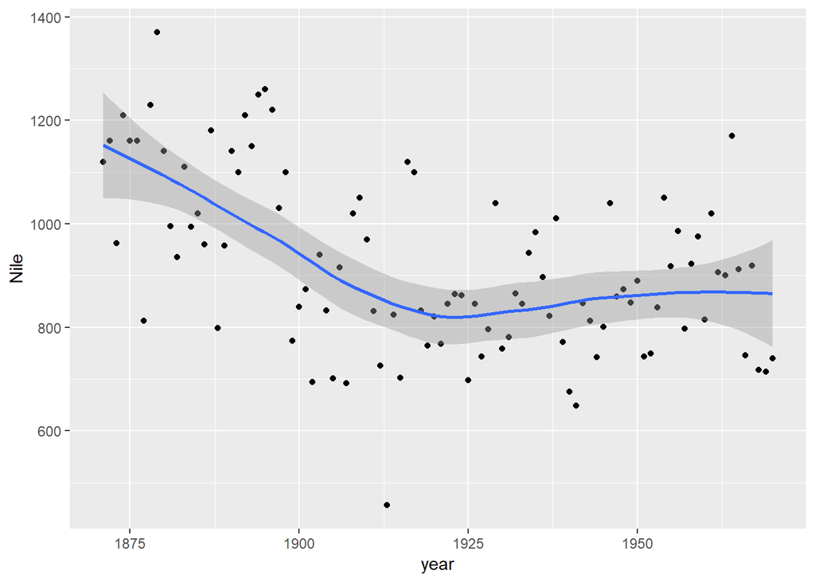

To assess if the river flow had a $change$ $point$, assume that the time series data $X$ of length $n$ has a mixture normal distribution: $X~\sim\sum_{i=1}^{n-1}N(\mu_{(i)},\sigma^2I_n)/(n-1)$,where $\mu_{(i)}$ is a mean vector with change point at $i$, $\mu_{(i)}=[\mu_1I(j\leq{i})+\mu_2I(j>i)]_{j=1,2,...,n}$,that is,

$$\mu_{(1)} = \left[\begin{array}
{r}
\mu_1\\
\mu_2\\
\mu_2\\
.\\.\\.\\
\mu_2\\
\mu_2\\\end{array}\right],
\mu_{(2)} = \left[\begin{array}
{r}
\mu_1\\
\mu_1\\
\mu_2\\
.\\.\\.\\
\mu_2\\
\mu_2\\\end{array}\right],...,
\mu_{(n-1)} = \left[\begin{array}
{r}
\mu_1\\
\mu_1\\
\mu_1\\
.\\.\\.\\
\mu_1\\
\mu_2\\\end{array}\right]$$

Alternatively, we can represent the mixture using an indicator variable $Z \in \big\{1,...,n-1\big\}$, with $\mathbf{P}(Z=1)=...=\mathbf{P}(Z=n-1)=1/(n-1)$,for the location of the change point:

$$X_j|Z \stackrel{iid}\sim N\Big(\mu_1I(j\leq{Z})+\mu_2I(j>Z),\sigma^2\Big), j=1,2,...,n$$

Thus, we need to estimate $\theta=(\mu_1,\mu_2,\sigma^2)$, and under the latent formulation we can use expectation-maximization.

1. Write down the log-likelihood and show that, up to a constant,

$$\begin{split}
Q(\theta;\theta^{(t)}) & = -\frac{n}{2}\log{\sigma^2}-\frac{1}{2\sigma^2}\sum_{i=1}^{n-1}\mathbf{E}_{Z|X;\theta^{(t)}}\big[I(Z=i)\big](X-\mu_{(i)})^\top(X-\mu_{(i)})\\
&= -\frac{n}{2}\log{\sigma^2}-\frac{1}{2\sigma^2}\sum_{j=1}^{n}\bigg\{\mathbf{E}_{Z|X;\theta^{(t)}}\big[I(j\leq{Z})\big](X_j-\mu_{(1)})^2+\mathbf{E}_{Z|X;\theta^{(t)}}\big[I(j>{Z})\big](X_j-\mu_{(2)})^2\bigg\}\\
\end{split}$$

Let’s first define: $Z_i$ as the indicator vector $Z=i$, $Z_i\in \big\{0,1\big\}$and we have the following distribution:

$$X|Z_i\stackrel{iid}\sim N\Big(\mu_{(i)},\sigma^2\Big), i = 1,2,...,n-1$$
$$X_j|Z\stackrel{iid}\sim N\Big(\mu_1I(j\leq{Z})+\mu_2I(j>Z),\sigma^2\Big)$$
Thus we calculate the likelihood function by the theory of mixture of Gaussian:

$$\begin{split}L(\theta;X,Z) & =\prod_{i=1}^{n-1}\phi(X;\mu_{(i)},\sigma^2I_n)^{Z_i}p(Z_i)\\
& =(\frac{1}{n-1})^{(n-1)}\prod_{i=1}^{n-1}\phi(X;\mu_{(i)},\sigma^2I_n)^{Z_i}\\\end{split}$$

By taking log to both side of the equation, we get the log-likelihood function:

$$\begin{split}l(\theta;X,Z) & =\sum_{i=1}^{n-1}Z_i\log\phi(X;\mu_{(i)},\sigma^2I_n)-(n-1)\log{(n-1)}\\
& = \sum_{i=1}^{n-1}Z_i\log\Big(\frac{1}{\sqrt{2\pi\sigma^2I_n}}e^{-\frac{(X-\mu_{(i)})^\top I_n(X-\mu_{(i)})}{2\sigma^2}}\Big)+C\\
& = \sum_{i=1}^{n-1}Z_i\Big(-\frac{1}{2}\log{2\pi}-\frac{1}{2}\log{\sigma^2I_n}-\frac{1}{2\sigma^2}(X-\mu_{(i)})^\top I_n(X-\mu_{(i)})\Big)+C\\
& = -\frac{n}{2}\log{\sigma^2}-\frac{1}{2\sigma^2}\sum_{i=1}^{n-1}I(Z=i)(X-\mu_{(i)})^\top (X-\mu_{(i)})+C.....................................(1)\\
& = -\frac{n}{2}\log{\sigma^2}-\frac{1}{2\sigma^2}\sum_{i=1}^{n-1}I(Z=i)\sum_{j=1}^{n}\bigg\{I(j\leq{i})(X_i-\mu_{(1)})^2+I(j>{i})(X_i-\mu_{(2)})^2\bigg\}\\
& = -\frac{n}{2}\log{\sigma^2}-\frac{1}{2\sigma^2}\sum_{j=1}^{n}\bigg\{I(j\leq{Z})(X_j-\mu_{(1)})^2+I(j>{Z})(X_j-\mu_{(2)})^2\bigg\}+C...................(2)\\\end{split}$$

Next, we carry out the E-step by taking expectation of the log-likelihood function with respect to $Z$ in equation $(1)$ and $(2)$ and get $Q(\theta,\theta^{(t)})$:

$$\begin{split}
Q(\theta;\theta^{(t)}) & = -\frac{n}{2}\log{\sigma^2}-\frac{1}{2\sigma^2}\sum_{i=1}^{n-1}\mathbf{E}_{Z|X;\theta^{(t)}}\big[I(Z=i)\big](X-\mu_{(i)})^\top(X-\mu_{(i)})+C\\
&= -\frac{n}{2}\log{\sigma^2}-\frac{1}{2\sigma^2}\sum_{j=1}^{n}\bigg\{\mathbf{E}_{Z|X;\theta^{(t)}}\big[I(j\leq{Z})\big](X_j-\mu_{(1)})^2+\mathbf{E}_{Z|X;\theta^{(t)}}\big[I(j>{Z})\big](X_j-\mu_{(2)})^2\bigg\}+C\\
\end{split}$$

2. Show that the E-step defines:
   $$\pi_i^{(t)}=\mathbf{E}_{Z|X;\theta^{(t)}}\big[I(Z=i)\big]=\frac{\exp\big\{-(X-\mu_{(i)}^{(t)})^\top (X-\mu_{(i)}^{(t)})/(2\sigma^{2(t)})\big\}}{\sum_{k=1}^{n-1}\exp\big\{-(X-\mu_{(k)}^{(t)})^\top (X-\mu_{(k)}^{(t)})/(2\sigma^{2(t)})\big\}}$$

where $\mu_{(i)}^{(t)}=[\mu_1^{(t)}I(j\leq{i})+\mu_2^{(t)}I(j>i)]_{j-1,2,...,n}$ and thus $\mathbf{E}_{Z|X;\theta^{(t)}}\big[I(j\leq{Z})\big]=\sum_{i=j}^{n-1}\pi_i^{(t)}$ and $\mathbf{E}_{Z|X;\theta^{(t)}}\big[I(j>{Z})\big]=\sum_{i=1}^{j-1}\pi_i^{(t)}$. Note that you need to compute $\log{\pi_i^{(t)}}$ all along to avoid underflows.

As indicated by (a) in question 1:

$$\begin{split} \pi_i^{(t)} & =\frac{\mathbf{P}(X|Z_i=1;\theta^{(t)})\mathbf{P}(Z_i=1;\theta^{(t)})}{\sum_{{\tilde{Z}_i}}\mathbf{P}(X|\tilde{Z_i};\theta^{(t)})\mathbf{P}(\tilde{Z_i};\theta^{(t)})}\\
& = \frac{\phi(X;\mu_{(i)}^{(t)},\sigma^{2{(t)}}I_n)\mathbf{P}(Z_i=1;\theta^{(t)})}{\sum_{k=1}^{n-1}\sum_{{\tilde{Z}_k}}\phi(X;\mu_{(k)}^{(t)},\sigma^{2{(t)}}I_n)\mathbf{P}(\tilde{Z}_k;\theta^{(t)})}\\
& = \frac{\phi(X;\mu_{(i)}^{(t)},\sigma^{2{(t)}}2I_n)\frac{1}{n-1}}{\sum_{k=1}^{n-1}\phi(X;\mu_{(k)}^{(t)},\sigma^{2{(t)}}I_n)\frac{1}{n-1}}\\
& = =\frac{\exp\big\{-(X-\mu_{(i)}^{(t)})^\top (X-\mu_{(i)}^{(t)})/(2\sigma^{2(t)})\big\}}{\sum_{k=1}^{n-1}\exp\big\{-(X-\mu_{(k)}^{(t)})^\top (X-\mu_{(k)}^{(t)})/(2\sigma^{2(t)})\big\}}\end{split}$$

3. Derive the M-step for the updates and show that:

$$\mu_1^{(t+1)}=\frac{\sum_{j=1}^n\mathbf{E}_{Z|X;\theta^{(t)}}\big[I(j\leq Z)\big]X_j}{\sum_{j=1}\mathbf{E}_{Z|X;\theta^{(t)}}\big[I(j\leq Z)\big]},
\mu_2^{(t+1)}=\frac{\sum_{j=1}^n\mathbf{E}_{Z|X;\theta^{(t)}}\big[I(j> Z)\big]X_j}{\sum_{j=1}\mathbf{E}_{Z|X;\theta^{(t)}}\big[I(j> Z)\big]},\text{and }
\sigma^{2(t+1)}=\frac{1}{n}\sum_{i=1}^{n-1}\pi_i^{(t)}(X-\mu_{(i)}^{(t+1)})^\top (X-\mu_{(i)}^{(t+1)})$$

Take derivative of $Q(\theta;\theta^{(t)})$ in part (a) with respect to $\mu_1,\mu_2,\sigma^2$, we have:

$$\begin{split} \frac{\partial{Q(\theta;\theta^{(t)})}}{\partial\mu_1}(\mu_1^{(t+1)}) &=-\frac{1}{2\sigma^2}\sum_{j=1}^{n}\mathbf{E}_{Z|X;\theta^{(t)}}\big[I(j\leq Z)\big](-2(X_j-\mu_1^{(t+1)}))\\
&=\frac{1}{\sigma^2}\Big\{\sum_{j=1}^{n}\mathbf{E}_{Z|X;\theta^{(t)}}\big[I(j\leq Z)\big]X_j-\sum_{j=1}^{n}\mathbf{E}_{Z|X;\theta^{(t)}}\big[I(j\leq Z)\big]\mu_1^{(t+1)}\Big\}=0\\\end{split}$$

Therefore, with the same idea, we have

$$\mu_1^{(t+1)}=\frac{\sum_{j=1}^n\mathbf{E}_{Z|X;\theta^{(t)}}\big[I(j\leq Z)\big]X_j}{\sum_{j=1}\mathbf{E}_{Z|X;\theta^{(t)}}\big[I(j\leq Z)\big]},
\mu_2^{(t+1)}=\frac{\sum_{j=1}^n\mathbf{E}_{Z|X;\theta^{(t)}}\big[I(j> Z)\big]X_j}{\sum_{j=1}\mathbf{E}_{Z|X;\theta^{(t)}}\big[I(j> Z)\big]}$$

Take derivative of $Q$ w.r.t. $\sigma^2$, we have

$$\begin{split}\frac{\partial{Q(\theta;\theta^{(t)})}}{\partial{\sigma^2}}(\sigma^{2(t+1)})&=-\frac{n}{2\sigma^{2(t+1)}}+\frac{1}{2\sigma^{4(t+1)}}\sum_{i=1}^{n-1}\mathbf{E}_{Z|X;\theta^{(t)}}\big[I(Z=i)\big](X-\mu_{(i)}^{(t+1)})^\top(X-\mu_{(i)}^{(t+1)})\\
&=-\frac{n}{2\sigma^{2(t+1)}}+\frac{1}{2\sigma^{4(t+1)}}\sum_{i=1}^{n-1}\pi_i^{(t)}(X-\mu_{(i)}^{(t+1)})^\top(X-\mu_{(i)}^{(t+1)})\\
&=-\frac{n}{2}+\frac{1}{2\sigma^{2(t+1)}}\sum_{i=1}^{n-1}\pi_i^{(t)}(X-\mu_{(i)}^{(t+1)})^\top(X-\mu_{(i)}^{(t+1)})=0\\\end{split}$$

Therefore, we have $\sigma^{2(t+1)}=\frac{1}{n}\sum_{i=1}^{n-1}\pi_i^{(t)}(X-\mu_{(i)}^{(t+1)})^\top (X-\mu_{(i)}^{(t+1)})$

4. Now apply your EM algorithm to the Nile dataset. Start with $\mu_1^{(0)}$ as the mean of the first half of the series, $\mu_2^{(0)}$ as the mean for the second half, and $\sigma^{2(0)}=(\sum_{j=1}^{n/2}(X_j-\mu_1^{(0)})^2+\sum_{j=n/2+1}^{n}(X_j-\mu_2^{(0)})^2)/n$ and iterate until convergence. Take a relative precision of $10^{-6}$ as stopping criterion.

What are your EM estimates $\hat\mu_1,\hat\mu_2$ and $\hat\sigma^2$? To better visualize the estimates, make two plots: one with $\pi_i^{(T)}$ at the last iteration $T$ over years, to access the change point location; and other plot with the time series data and two horizontal lines for $\hat\mu_{(i^*)}$, where $i^*$ is the year that maximizes $\pi^{(T)}$ (the two horizontal lines correspond to the EM estimates for $\mu_1$ up to $i^*$ and $\mu_2$ from $i^*$ to the end of the series). For the last plot, also add confidence bands of $\pm{\hat\sigma}$

```r
mu.mat <- function(x,mu1,mu2) {
  n <- length(x)
  mu.full <- c(mu1,rep(mu2,(n-1)))
  for (i in 2:(n-1)) {
    mu.new <- c(rep(mu1,i),rep(mu2,(n-i)))
    mu.full <- unname(cbind(mu.full,mu.new))
  }
  mu.full
}

pi.mat <- function(x,mu1,mu2,sigma2) {
  mu_mat <- mu.mat(x,mu1,mu2)
  x_mu <- -(replicate((length(x)-1),x)-mu_mat)^2/(2*sigma2)
  exp(apply(x_mu,2,sum))/sum(exp(apply(x_mu,2,sum)))
}

pi.mu1.comb <- function(x,mu1,mu2,sigma2) {
  pimat <- pi.mat(x,mu1,mu2,sigma2)
  pi.list <- NULL
  for (i in 1:(length(x)-1)) {
    sum.pi <- sum(pimat[i:(length(x)-1)])
    pi.list <- c(pi.list,sum.pi)
  }
  c(pi.list,0)
}

pi.mu2.comb <- function(x,mu1,mu2,sigma2) {
  pimat <- pi.mat(x,mu1,mu2,sigma2)
  pi.list <- NULL
  for (i in 1:(length(x)-1)) {
    sum.pi <- sum(pimat[1:i])
    pi.list <- c(pi.list,sum.pi)
  }
  c(0,pi.list)
}

em.gauss.update <- function(x,mu1,mu2,sigma2,iteration=50,tolerance=1e-6) {
  mu1.cur <- mu1;mu2.cur <- mu2;sigma2.cur <- sigma2
  for (it in 1:iteration) {
    print(paste0("mu1 is: ",mu1.cur," mu2 is: ",mu2.cur," sigma2 is: ",sigma2.cur))
    pi.cur <- pi.mat(x,mu1.cur,mu2.cur,sigma2.cur)
    pi.mu1.cur <- pi.mu1.comb(x,mu1.cur,mu2.cur,sigma2.cur)
    pi.mu2.cur <- pi.mu2.comb(x,mu1.cur,mu2.cur,sigma2.cur)
    mu1.nxt <- sum(pi.mu1.cur * x)/sum(pi.mu1.cur)
    mu2.nxt <- sum(pi.mu2.cur * x)/sum(pi.mu2.cur)
    mu.mat.nxt <- mu.mat(x,mu1.nxt,mu2.nxt)
    sigma2.nxt <- sum(pi.cur * apply((replicate((length(x)-1),x)-mu.mat.nxt)^2,2,sum))/length(x)
    if ((abs(mu1.nxt-mu1.cur)/mu1.cur)<tolerance|(abs(mu2.nxt-mu2.cur)/mu2.cur)<tolerance|(abs(sigma2.nxt-sigma2.cur)/sigma2.cur)<tolerance) break
    mu1.cur <- mu1.nxt
    mu2.cur <- mu2.nxt
    sigma2.cur <- sigma2.nxt
  }
  print(paste0("times =",it))
  list("mu1"=mu1.nxt,"mu2"=mu2.nxt,"sigma2"=sigma2.nxt,"pi"=pi.cur)
}

data("Nile")
xx <- as.vector(Nile)
n <- length(xx)
mu1 <- mean(xx[1:0.5*n])
mu2 <- mean(xx[(0.5*n+1):n])
sigma2 <- (sum((xx[1:0.5*n]-mu1)^2)+sum((xx[(0.5*n+1):n]-mu2)^2))/n
(nile_result <- em.gauss.update(xx,mu1,mu2,sigma2))
```

```
## [1] "mu1 is: 740 mu2 is: 854.38 sigma2 is: 5931.7778"
## [1] "mu1 is: 1120.03218293735 mu2 is: 917.320881025778 sigma2 is: 27944.3594748136"
## [1] "mu1 is: 1096.55560781223 mu2 is: 852.881840359374 sigma2 is: 16573.0368707226"
## [1] "mu1 is: 1097.23907087059 mu2 is: 850.78862774007 sigma2 is: 16155.2486910681"
## [1] "mu1 is: 1097.28634630556 mu2 is: 850.725611801198 sigma2 is: 16140.7945964508"
## [1] "mu1 is: 1097.28828345601 mu2 is: 850.723580201034 sigma2 is: 16140.3001612402"
## [1] "times =6"
```

```
## $mu1
## [1] 1097.288
##
## $mu2
## [1] 850.7235
##
## $sigma2
## [1] 16140.28
##
## $pi
##  [1] 7.579831e-23 1.299045e-21 1.098009e-21 4.039170e-20 6.922401e-19
##  [6] 1.186373e-17 1.014002e-18 5.063065e-17 2.145895e-14 2.709470e-13
## [11] 3.733946e-13 2.057718e-13 1.642968e-12 2.229864e-12 4.502179e-12
## [16] 3.634974e-12 8.455797e-11 5.835660e-12 4.569827e-12 5.769999e-11
## [21] 3.954345e-10 1.454657e-08 2.139838e-07 1.450255e-05 1.145122e-03
## [26] 4.907748e-02 1.154439e-01 7.911700e-01 3.726872e-02 4.811622e-03
## [31] 1.044261e-03 1.449204e-05 8.620242e-06 1.000059e-06 1.544496e-08
## [36] 6.367229e-09 8.570416e-11 1.730399e-10 5.524890e-10 5.118140e-10
## [41] 5.759030e-11 1.303081e-12 4.767572e-16 4.820515e-17 7.559432e-19
## [46] 7.031963e-18 4.819205e-17 5.506137e-18 2.226268e-19 2.150157e-20
## [51] 9.241412e-22 1.287827e-22 2.399003e-23 4.334464e-24 6.394305e-26
## [56] 8.910715e-27 2.654326e-28 1.749792e-29 4.795341e-29 1.796295e-30
## [61] 9.416583e-32 1.781153e-32 2.482106e-33 1.569452e-33 1.828323e-33
## [66] 5.638487e-34 5.529551e-35 9.582746e-35 4.311827e-36 4.545293e-38
## [71] 3.171997e-40 4.488347e-41 3.778065e-42 1.091547e-43 7.766880e-45
## [76] 2.128529e-44 3.730055e-45 8.095300e-46 1.181015e-46 3.272834e-47
## [81] 9.749126e-49 3.134582e-50 3.925164e-51 1.253243e-50 5.326816e-51
## [86] 6.397960e-51 4.282605e-52 1.964775e-52 1.994839e-52 1.757900e-53
## [91] 3.549266e-53 1.255908e-53 4.117231e-54 8.220801e-53 3.188160e-53
## [96] 9.791534e-55 4.225886e-55 8.461831e-57 1.593945e-58
```

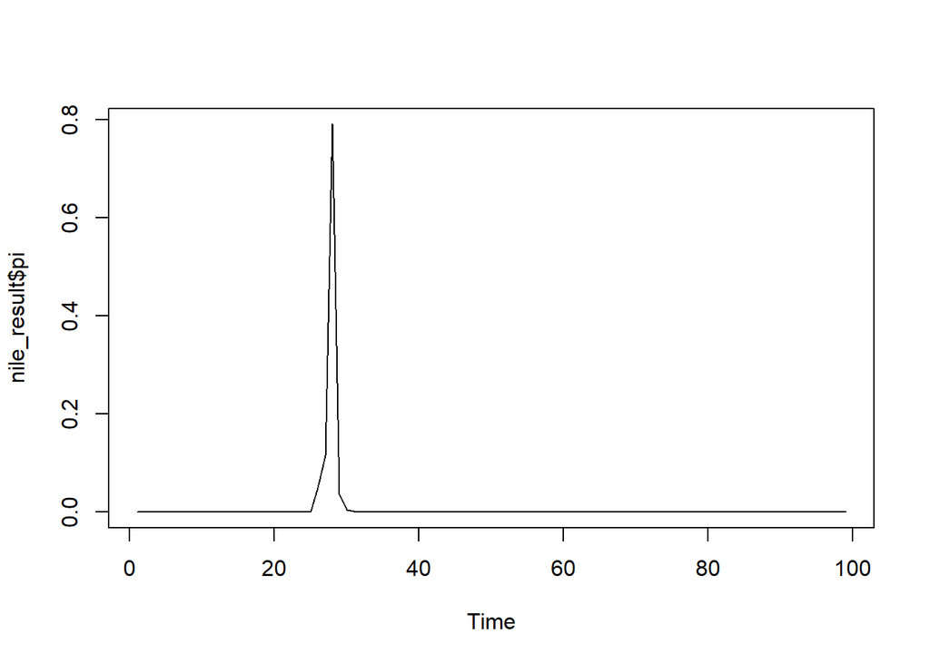

```r
plot.ts(nile_result$pi)
```

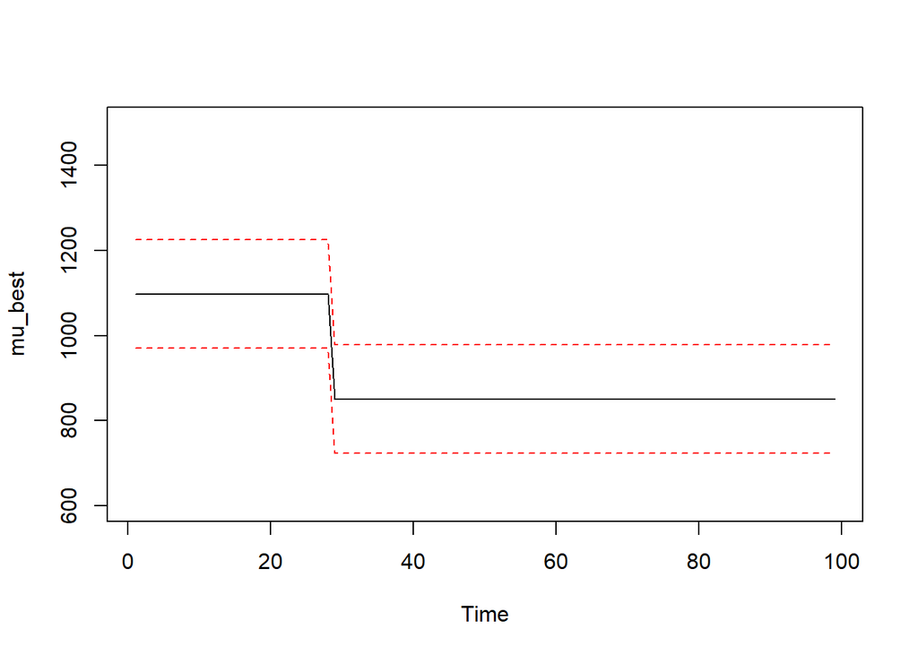

```r
# get the index for highest pi
istar <- match(max(nile_result$pi),nile_result$pi)
mu_best <- c(rep(nile_result$mu1,istar),rep(nile_result$mu2,(length(xx)-1-istar)))
upbond <- mu_best + sqrt(nile_result$sigma2)
lowbond <- mu_best - sqrt(nile_result$sigma2)
plot.ts(mu_best,ylim=c(600,1500))
lines(upbond,lty="dashed",col="red")
lines(lowbond,lty="dashed",col="red")
```